# Introduction to SeedSorter

## Introduction

SeedSorter is a package that facilitates the use of supervised and unsupervised classification algorithms to discriminate between seeds and non-seed plant particles that have been sorted with an Union Biometrica Biosorter large particle flow cytometer. This tutorial introduces the main functions of SeedSorter to train algorithms, tune hyperparameters, quantify prediction performance with error indices and perform predictions. A real life example of a more complex workflow can be found at https://github.com/AleMorales/SeedSorterPaper.

The only dependency for this tutorial is the SeedSorter package, which can be loaded into a new R session as follows:

```r
library(SeedSorter)
```

## Processing raw data

For each sorted sample, two types of files from the large particle flow cytometer are expected: a file with properties (such as time of flight or integral fluorescence) measured for each particle and a file with the complete profile of optical density of each particle. SeedSorter needs to know the locations of these two files associated with a sample.For the purpose of this tutorial, we will download the files from the Github repository mentioned in the above to a local folder `temporary`:

```r
dir.create("temporary")
download.file(url = "https://raw.githubusercontent.com/AleMorales/SeedSorterPaper/master/Input/Training/An1_A.txt", destfile = "temporary/An1_A.txt")
download.file(url = "https://raw.githubusercontent.com/AleMorales/SeedSorterPaper/master/Input/Training/An1_A_prf.txt", destfile = "temporary/An1_A_prf.txt")
```

The first step is to process the files with profile data in order to extract features that are useful for classification (rather than working with the raw profiles). This is achieved with the `processFile` function. This function will create a new file with the extension *fst* (from the fst package). The `processFile` function just takes the name of the file with the profile of optical density as input:

```r
processFile(file = "temporary/An1_A_prf.txt")
```

- A second sample of manually-separated seeds from the same genotype.
- A sample with only non-seed plant material that has been exposed to the same coarse-cleaning procedure as other samples.
- A sample with an unknown mix of seeds and non-seed plant material as example of unlabelled sample for which we want to make predictions.

The downloading and processing of these additional files is straightforward:

```r
# Download and process second seed sample
download.file(url = "https://raw.githubusercontent.com/AleMorales/SeedSorterPaper/master/Input/Training/An1_B.txt", destfile = "temporary/An1_B.txt")
download.file(url = "https://raw.githubusercontent.com/AleMorales/SeedSorterPaper/master/Input/Training/An1_B_prf.txt", destfile = "temporary/An1_B_prf.txt")
processFile(file = "temporary/An1_B_prf.txt")

# Download and process non-seed plant material sample
download.file(url = "https://raw.githubusercontent.com/AleMorales/SeedSorterPaper/master/Input/Training/waste.txt", destfile = "temporary/waste.txt")
download.file(url = "https://raw.githubusercontent.com/AleMorales/SeedSorterPaper/master/Input/Training/waste_prf.txt", destfile = "temporary/waste_prf.txt")
processFile(file = "temporary/waste_prf.txt")

# Download and process unlabelled sample (this file is already processed in the online repository)
download.file(url = "https://raw.githubusercontent.com/AleMorales/SeedSorterPaper/master/Input/Application/An-1/156_2_109_01_extra.txt", destfile = "temporary/unlabelled.txt")
download.file(url = "https://raw.githubusercontent.com/AleMorales/SeedSorterPaper/master/Input/Application/An-1/156_2_109_01_extra_ch0_prf.fst", destfile = "temporary/unlabelled_prf.fst", mode = "wb")
```

## Preparing trainig dataset

In order to train an algorithm we need two types of sorted samples:

- A sample that only contains seeds which has been obtained through manual separation under a dissecting microscope.
- A sample that only contains non-seed plant material that has been subject to the same cleaning procedure as normal samples.

Each sample will have two files associated to it, as explained above. The first step is to load the data and label the different particles as seed or waste (non-seed) particles. This is achieved with the `getTrainingData` function:

```r
data_train = getTrainingData(main_file = "An1_A.txt",
                       profile_file = "An1_A_prf.fst",
                       main_waste_file = "waste.txt",
                       profile_waste_file = "waste_prf.fst",
                       datadir = "temporary", clean = TRUE)
```

Note that we specify the names of each of the four files as well as the directory where these files are stored (argument `datadir`). It is important to assign the correct file to each argument to ensure that labelling is done correctly. Also, remember to use the files with `fst` extension for the profile data. There is an additional argument (`calibration`) that specifies the calibration coefficients to translate time of flight into particle size, but in this case we are relying on the default from SeedSorter (check help documentation on `getTrainingData` for details).

The last argument (`clean`) indicates whether the samples assumed to only have seeds should be cleaned by removing very small dust particles (usually < 100 μm) that are not detectable during manual separation and often stick to the surface of the seeds prior to sorting. This is achieved through the separation of the data into two groups via k-means clustering and retaining the group with higher average particle size. Always use `clean = TRUE` unless is is certain that there are no small dust particles.

The result of `getTrainingData` is a table with all the features that can be used to training the classification algorithms, plus the class of particles (`S` = seed particle, `W` = waste or non-seed particle):

```r
head(data_train)
```

```
## # A tibble: 6 x 8
##   Extinction rGreen rYellow     P    Px     C  Size Class
##        <dbl>  <dbl>   <dbl> <dbl> <dbl> <dbl> <dbl> <chr>
## 1      18.6   0.730   0.649  3764 0.261 0.697  90.9 W
## 2      20.7   0.818   0.614  3176 0.438 0.943  94.6 W
## 3      34.3   0.75    0.482  5052 0.490 0.867 116.  W
## 4       6.74  0.571   0.429  1344 0.362 0.919  62.7 W
## 5      21.6   0.303   0.686  2688 0.387 0.834 103.  W
## 6       2.64  1.2     0.6     380 0.136 0.752  49.4 W
```

In order to train the algorithms on these data, we first need to convert them into a *classification task* as implemented by the mlr package (which is the machine learning backend on which SeedSorter runs). This is achieved with the `createTrainingTask` function:

```r
task_train = createTrainingTask(data = data_train)
```

## Training an algorithm

Training an algorithm on a classification task is as simple as calling the `trainAlgorithm` function, passing the name of the algorithm:

```r
model = trainAlgorithm(algorithm = "xgboost", task = task_train, osw.rate = 3.5)
```

In this case we have trained the XGBoost algorithm with the data loaded earlier. The list of classification algorithms that can be trained in SeedSorter can be retrieved from the help documentation of the `trainAlgorithm` function. The argument `osw.rate` indicates the rate of oversampling to be performed for the smallest class. This is required to avoid biasing the model when trained on an unbalanced dataset. We can estimate the amount of oversampling needed by looking into the description of the classification task:

```r
task_train
```

```
## Supervised task: cleanseeds
## Type: classif
## Target: Class
## Observations: 3559
## Features:
##    numerics     factors     ordered functionals
##           7           0           0           0
## Missings: FALSE
## Has weights: FALSE
## Has blocking: FALSE
## Has coordinates: FALSE
## Classes: 2
##    S    W
##  788 2771
## Positive class: S
```

The last lines indicate the number of particles in each category and from this we can derive the need to oversample the minority class by 3.5 (the oversampling rate does not have to be very exact; small imbalances will not cause trouble).

## Testing the trained algorithm

After training an algorithm we always want to test how accurate the model is in making predictions on new samples. In order to be able to test the predictive performance of the model, this sample also needs to be labelled (i.e. the dataset for testing a model should have the same features as for training). Like before, the original raw data needs to be combined using the `getTrainingData` function:

```r
data_test = getTrainingData(main_file = "An1_B.txt",
                       profile_file = "An1_B_prf.fst",
                       main_waste_file = "waste.txt",
                       profile_waste_file = "waste_prf.fst",
                       datadir = "temporary", clean = TRUE)
task_test = createTrainingTask(data_test)
```

And making predictions with the model for this second sample is acomplished with the function `testModel`:

```r
model_test = testModel(model, task_test)
```

The predictive performance of the model can be retrieve from the returned object as:

```r
model_test$error
```

```
##         ber        mmce
## 0.002171237 0.001966845
```

## Hyperparameter tuning

The XGBoost algorithm (and others supported by SeedSOrter) can benefit from hyperparameter tuning, that is, from tuning the settings of the algorithm to improve predictive power. This can be achieved by using the function `tuneAlgorithm` rather than `trainAlgorithm`:

```r
tuned_model = tuneAlgorithm(algorithm = "xgboost", task = task_train, osw.rate = 3.5,
                            maxiter = 15L, lambda = 15L)
```

The optimal settings for the algorithm is calculated with an evolutionary optimization algorithm (CMA-ES) which settings are controlled by `maxiter` (maximum number of iterations) `lambda` (number of offspring per generation). To avoid overestimation of predictive performance, the data is split into 5 subsets of equal size using a stratified cross-validation technique.

We can now test the model on the second sample and quantify the prediction error and confirm that these are lower that for the original non-tuned model:

```r
tuned_model_test = testModel(tuned_model, task_test)
cbind(`non-tuned` = model_test$error, tuned = tuned_model_test$error)
```

```
##        non-tuned        tuned
## ber  0.002171237 0.0007217611
## mmce 0.001966845 0.0011239112
```

## Predictions on unlabelled samples

Once we have trained and tested an algorithm to quantify its predictive performance, we can use the trained model to make predictions for new samples of unlabelled data (i.e. samples for which manual separation was not applied). The procedure to prepare the data for the model is somewhat different to training and testing. We use the `getPredictionData` function and pass the two files associated to the unlabelled sample:

```r
unlabelled_data = getPredictionData(main_file = "unlabelled.txt",
                                    profile_file = "unlabelled_prf.fst",
                                    datadir = "temporary")
```

The prediction for unlabelled data is then performed with the `classifySeeds` function:

```r
prediction = classifySeeds(model = tuned_model, data = unlabelled_data)
```

Obviously, we cannot calculate the prediction errors as we do not know the true nature of each particle. However, we can extract the class predicted for each particle from the returned object and append it to the unlabelled data:

```r
predicted_class = as.data.frame(prediction)
unlabelled_data = transform(unlabelled_data, prediction = predicted_class$response)
```

We can now see that the predicted class has been added to each row:

```r
head(unlabelled_data)
```

```
##   Extinction     rGreen   rYellow     P        Px         C    Size prediction
## 1       6.48 0.46153846 1.6153846  1088 0.4655172 0.8994030  62.745          W
## 2     530.00 0.01124297 0.3185509 41420 0.3087349 0.8909932 286.965          S
## 3     483.00 0.01684239 0.1774613 46936 0.5268199 0.9221998 234.425          S
## 4       6.37 0.17142857 0.4285714  2512 0.3260870 0.8724212  58.305          W
## 5       7.84 0.70588235 0.5294118  4244 0.4130435 0.8834883  58.305          W
## 6      10.20 0.07526882 0.9569892  2520 0.3974359 0.8807999  70.145          W
```

And we can use this to calculate the number of particles in each category:

```r
table(unlabelled_data$prediction)
```

```
##
##    S    W
## 3303 1627
```

Retrieve the median size of seeds in the sample:

```r
median(subset(unlabelled_data, prediction == "S")$Size)
```

```
## [1] 340.245
```

Or plot the distribution of seed sizes:

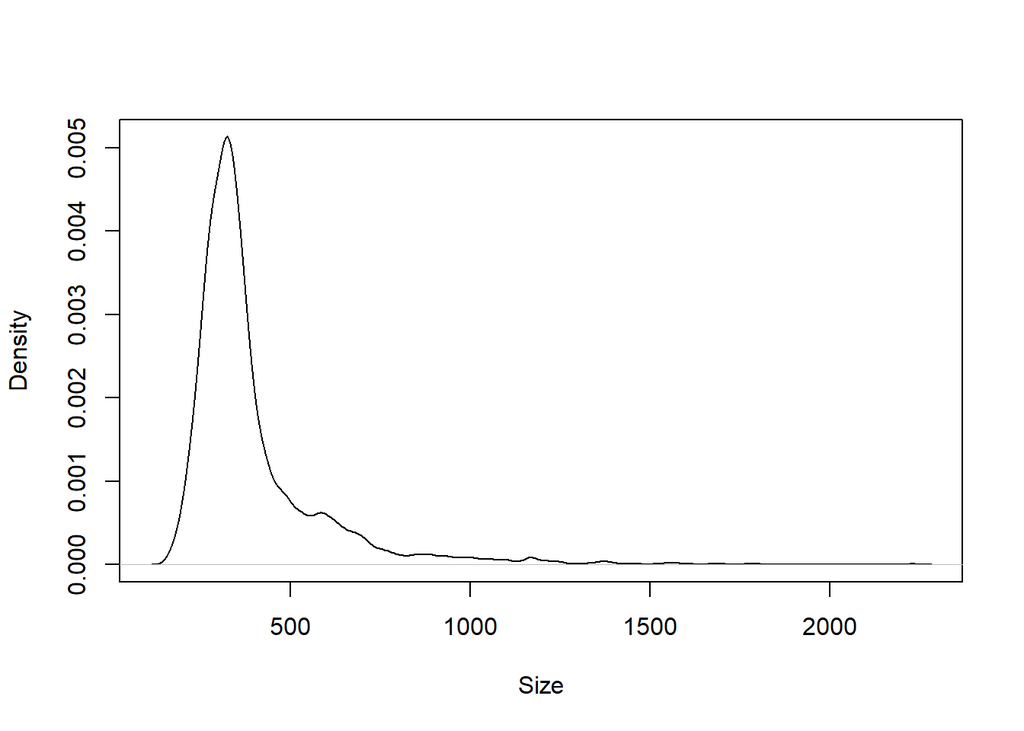

```r
plot(density(subset(unlabelled_data, prediction == "S")$Size), xlab = "Size", main = "")
```